# Data Analysis report

**May 30, 2020**

## Overview:

- Analyze and communicate insights of cleaned dataset.

Using the clean dataset I wanted to answer the question: **What is/are the factor(s) of most rating dogs?**

First, I had to get the most rated dogs which are the dogs with highest rating_numerator and saved the dataframe to most_rated using this line of code:

`most_rated = df[df.rating_numerator==df.rating_numerator.max()]`

To answer the above question, I thought of exploring the dog_stage feature and see how it is related to most rating dogs and got these results.

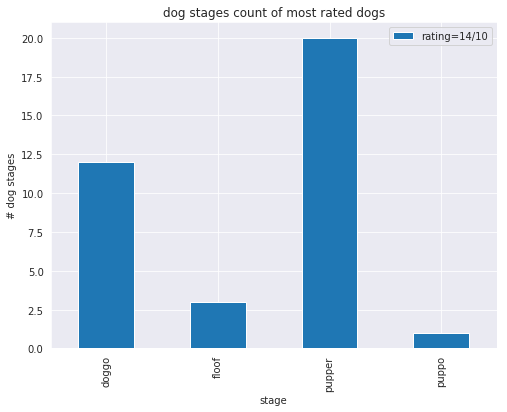

We can see that **pupper** stage is the most rated dog stage, let's dig deeper

Among those dog_stages I wanted to know **which dog_stage received the most likes on twitter.**

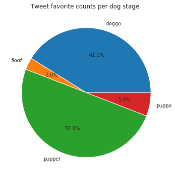

Clearly **pupper** dog stage has the most favorite count among the most rated dogs, then comes doggo and lastly puppo and floof. But what is really the difference between these stages? We won't know until we see them side by side.

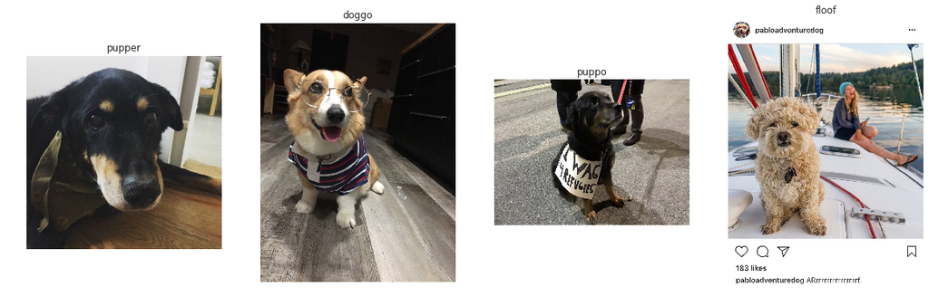

For me they all look cute! But based on the definition of a pupper, people might favor this dog stage because of the age of the dog.

> Pupper: A small doggo, usually younger. Can be equally, if not more mature than some doggos

Next, I wanted to explore the dog breeds of the most rated dogs. I ended up with these results:

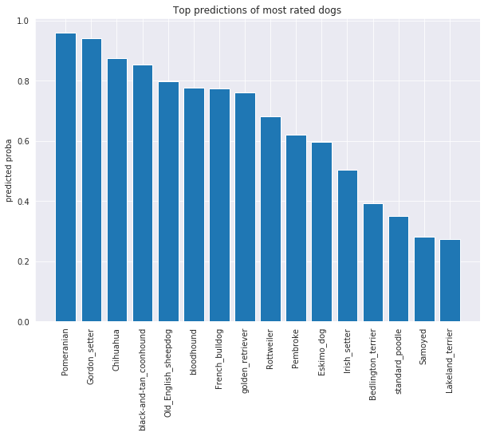

Top 3 predicted dog breeds are:

- Pomeranian
- Gordon Setter
- Chihuahua

These dog breeds share a common key factor, which is their **small size**

To answer the question stated above, **size** and **dog_stage** are important key factors to favor one dog over another. **People tend to favor smaller and younger dogs**.

**What words, do tweets of most rated dogs share in common?**

- to answer this question we can visualize the most common words of these tweets

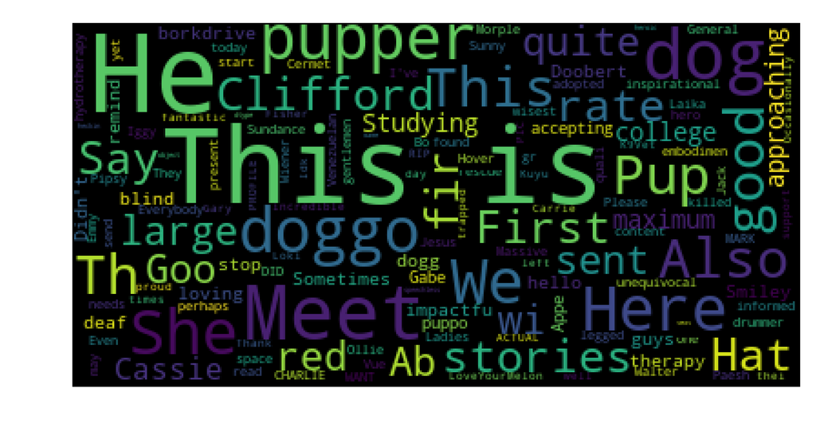